# Cod and Capelin Distribution and Abundance in the Barents Sea in 2013

Janelle Morano

5/8/2020

# 1 Introduction

Northeast Arctic cod (*Gadus morhua*) and Barents Sea capelin (*Mallotus villosus*) are important Norwegian commercial fisheries stocks in the Barents Sea. Cod is a generalist predator, but has a preference for capelin and is the main predator on post-larval capelin. Cod also feeds on immature cod. This predator-prey interaction is incorporated into the management of both fisheries in Norway.

The distribution of cod and capelin in the Barents Sea varies seasonally between spawning grounds and high-productivity feeding areas. The northern Barents Sea is ice-covered in the winter. When the ice melts and recedes in the spring, zooplankton production blooms, and capelin migrate northward from their spawning grounds to feed. Cod move northward after spawning farther south, following after capelin. In early fall, as the zooplankton production decreases, both species begin migrating back south. Cod predation on capelin is higher in the winter than the summer.

Both species spawn in early spring. Capelin spawns along the northern coast of Norway and Russia, and cod’s main spawning ground is further south along the Norwegian coast in the Lofoten area.

Cod abundance has been increasing over the past decade, and their distribution has been expanding northward, potentially impacting capelin. The Norwegian stock assessment model for cod and capelin relies on several assumptions related to the seasonal interaction between cod and capelin, but does not explicitly incorporate spatial distribution and overlap of the two species. In the last couple of decades, water temperatures increased, cod biomass doubled, and the capelin stock collapsed twice. Understanding the seasonal and annual distribution and abundance of cod and capelin could inform stock assessments and inform future planning for sustainable harvesting.

My dissertation is about marine ecosystem responses to climate change, specifically how changes in species’ distributions, movements, and abundance changes ecosystems. Understanding this will inform how to sustainable fisheries management practices can respond. The purpose of this study is to explore the spatial distribution of cod and capelin in one year, to explore the relationship between these species and environmental factors. Fall et al. 2018 modeled the seasonality of the spatial distribution and abundance of cod and capelin, from 2004-2015. Here, I am using the available data to explore the patterns of spatial distribution, abundance, and overlap of cod and capelin in the autumn of 2013. I will apply multiple spatial analysis methods to understand the approaches, interpretations, and limitations, and look for how to expand the analyses to address temporal changes.

# 2 Research Questions

1. What is the spatial distribution and abundance of cod and capelin in the Barents Sea?
2. What factors influence these patterns?

## 2.1 Objectives:

1. What is the abundance and distribution of capelin and cod across the Barents Sea?
2. How much do they overlap? Are there patterns in overlap?
3. Are there correlations with water temperature or depth?
4. Reconstruct, in part, the methods and results of Fall et al. 2018 to be able to understand and explore further, the Barents Sea ecosystem and general approaches to the spatial distribution of fishereies.

# 3 Methods

## 3.1 Data

Data are from the Norwegian ecosystem survey (2004-2015) covering the whole shelf in the main feeding season 3.1. These are some of the data by Fall et al. 2018 and available from [Dryad Digital Repository](https://doi.org/10.5061/dryad.pv3rc1m). The ecosystem survey occurs (August-October) and is a stratified-random bottom trawl survey, sampling at 217 fixed locations in the Barents Sea and around Svalbard. A Campelen demersal shrimp trawls are equipped with Simrad EK60 echo sounders to integrate acoustic backscatter sampling into swept area abundance estimates. CTD and depth measurements are also done on the trawl.

Cod and capelin densities (number of individuals/nmi^2) were estimated using standard methods for cod swept area calculation in the Barents Sea, that is, number caught at each trawl station divided by trawled area, assuming that the effective fishing width along the trawled transect is dependent on cod length

Data are acoustic backscatter of capelin and total density of immature and mature cod (ecosystem survey: mature cod >75 cm), bottom depth (m), bottom temperature (Celsius), and pelagic temperature (Celsius).

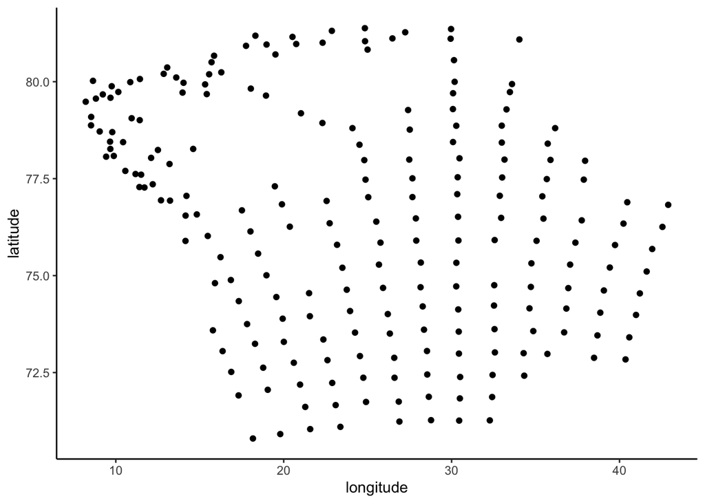

Figure 3.1: 217 survey sites in Barents Sea, 2013. Note that coastline references and other map labeling is missing due to my difficulty setting the correct polar projection.

## 3.2 Biological and Environmental Factors

Mature cod, immature cod, capelin, bottom depth, bottom water temperature, and pelagic water temperature were correlated to look for relationships among factors.

A linear model of the significantly correlated data was constructed in R, excluding highly covarying factors.

## 3.3 Spatial Analyses

Ordinary kriging in the sp package in R was applied to the mature cod, immature cod, and capelin densities across the survey area. To account for the zero-skewed distribution of each species’ abundance, the data were transformed by adding 1 and then log-transforming.

The variogram was fit using a spherical model in gstat in R over a 100x100 grid.

# 4 Results

High abundance of mature cod, immature cod, and capelin was generally in the northern regions of the survey area 4.1. Each species’ data were zero-skewed, meaning there were many sites with no reports of the fish species. There were some sites without any of the fish species, in the southwest and northern most sites.

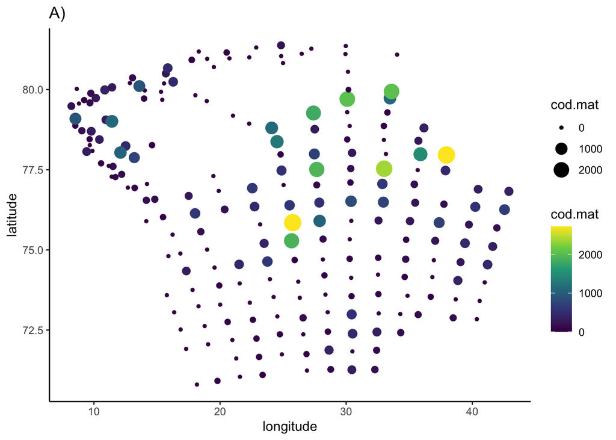

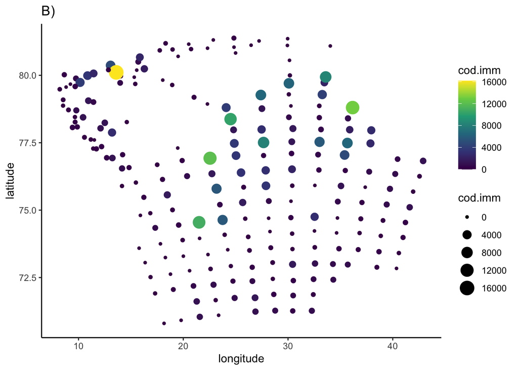

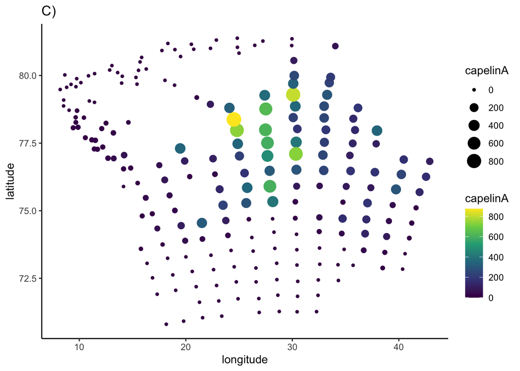

Figure 4.1: Abundance (number of individuals/nm^2) of A) mature cod, B) immature cod, and C) capelin at survey sites in Barents Sea in 2013.

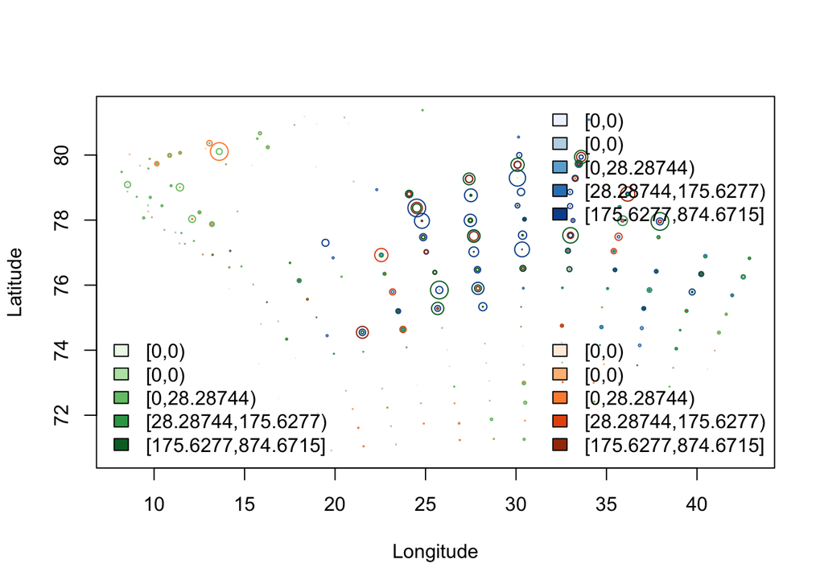

Figure 4.2: Co-occurring abundance (number of individuals/nm^2) of mature cod (green), immature cod (orange), and capelin (blue) at survey sites. Note that I recognize this figure is difficult to read and unattractive, thus I plan on improving it.

All three species co-occur at many sites, but the relative abundance of each species varies at sites 4.2. The highest abundance and overlap appears in the central region of the survey area.

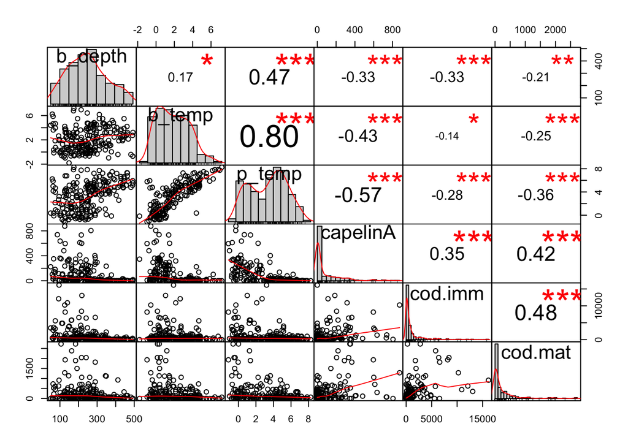

Figure 4.3: Correlation of factors (b_depth = bottom depth, b_temp = bottom temperature, capelinA = capelin density, cod.imm = immature cod density, cod.mat = mature cod density) along the diagonal. The bottom row is mature cod (y-axis) against each factor in the column (x-axis). The right-most column is the correlation of mature cod to each factor in the row. Mature cod is significanly correlated to all factors. Bottom and pelagic temperature are strongly co-varying.

Mature cod are significantly positively correlated with immature cod and capelin, and significantly negatively correlated with bottom depth, bottom temperature, and pelagic temperature 4.3. Bottom temperature and pelagic temperature are highly correlated (R=0.80) and co-vary. With a lower negative correlation to mature cod, bottom temperature was excluded from the model.

Lm = log(Mature Cod + 1) ~ Capelin + Immature Cod + bottom depth + pelagic temp

```
##
## Call:
## lm(formula = log(cod.mat + 1) ~ capelinA + cod.imm + b_depth +
##     p_temp, data = datai)
##
## Residuals:
##    Min     1Q Median     3Q    Max
## -5.744 -2.578  1.120  2.157  4.357
##
## Coefficients:
##               Estimate Std. Error t value Pr(>|t|)
## (Intercept)  2.9920984  0.5714106   5.236 3.94e-07 ***
## capelinA     0.0029706  0.0013505   2.200   0.0289 *
## cod.imm      0.0003754  0.0000823   4.562 8.58e-06 ***
## b_depth     -0.0005815  0.0018907  -0.308   0.7587
## p_temp      -0.0733092  0.0929808  -0.788   0.4313
## ---
## Signif. codes:  0 '***' 0.001 '**' 0.01 '*' 0.05 '.' 0.1 ' ' 1
##
## Residual standard error: 2.543 on 212 degrees of freedom
## Multiple R-squared:  0.1967, Adjusted R-squared:  0.1815
## F-statistic: 12.97 on 4 and 212 DF,  p-value: 1.815e-09
```

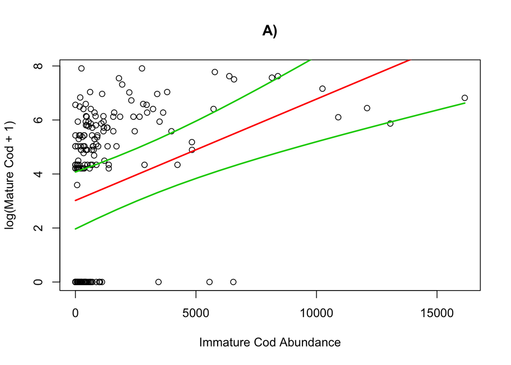

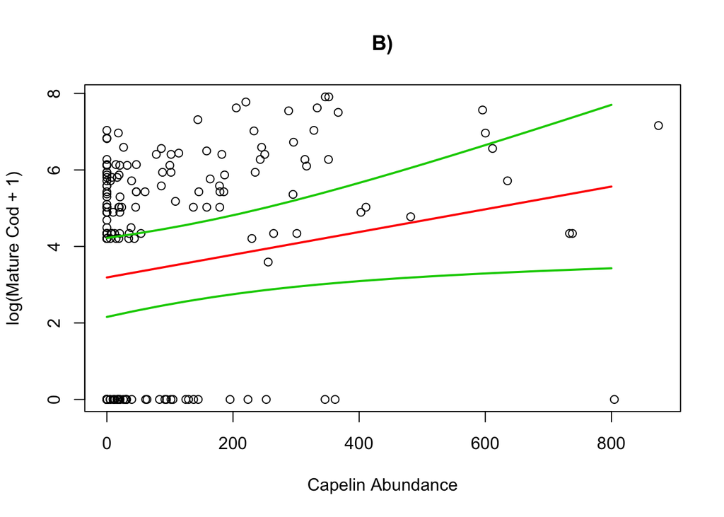

The abundance of mature cod (as log(mature cod + 1)) is significantly increasing as a function of increasing immature cod and capelin (immature cod = p<0.001; capelin = p=0.0289) 4.4. The variances are large and may be skewed, so this model needs to be explored further. The spatial correlation should be incorporated into the model to improve the fit.

Fitted variograms with a spherical model of the distances between points are reasonable, but maybe the capelin fit could be improved 4.5.

The kriged predicted abundance for mature cod, immature cod, and capelin, mature and immature cod have similar patterns of abundance and spatial distribution 4.6. The highest predicted abundance of mature and immature cod largely overlap, with a region of higher abundance to the northeast. It appears that capelin may have higher abundance between 2 regions of high abundance of mature and immature cod.

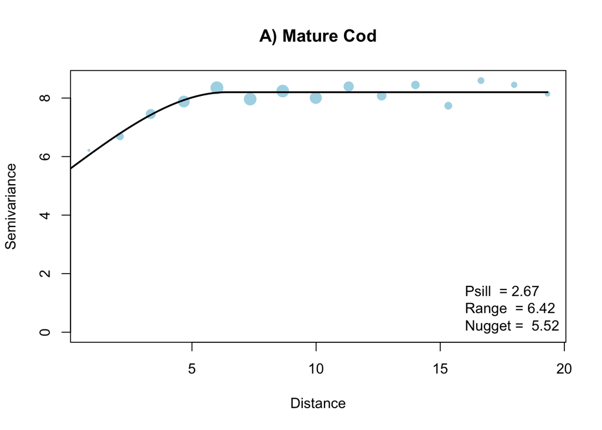

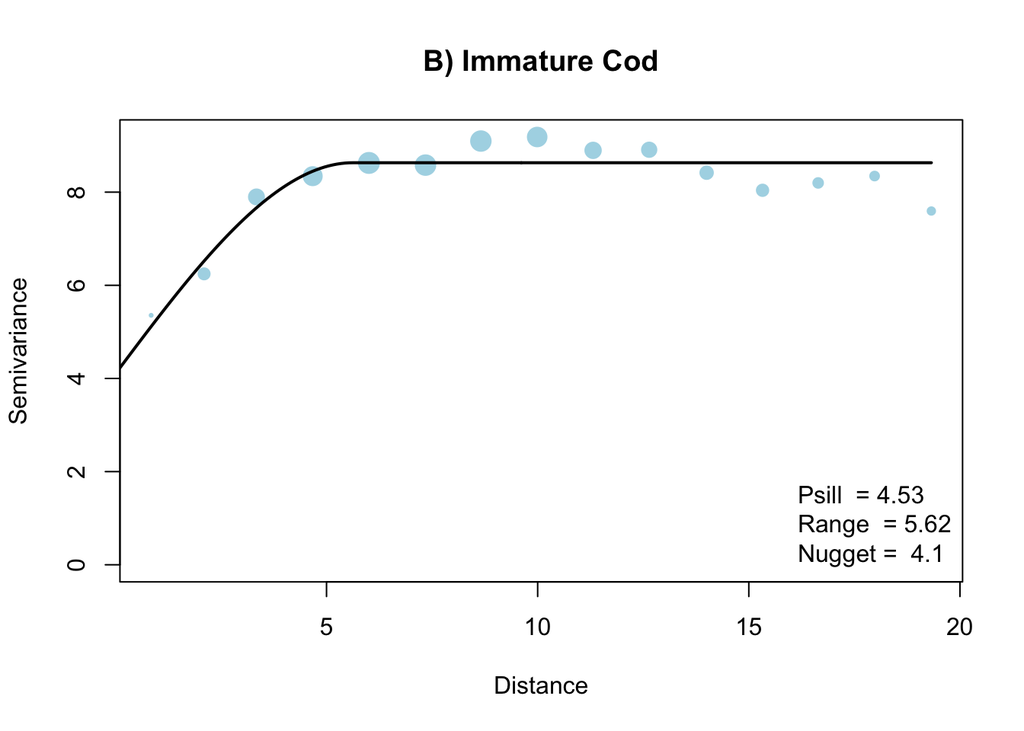

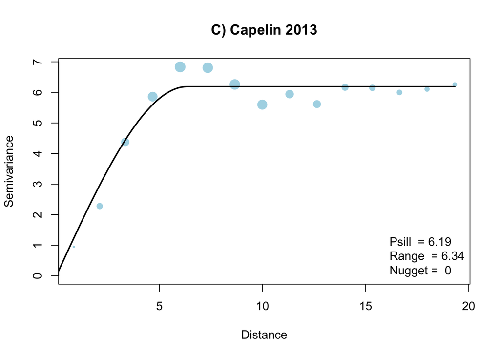

Figure 4.5: Variograms for A) mature cod, B) immature cod, and C) capelin distribution across survey sites.

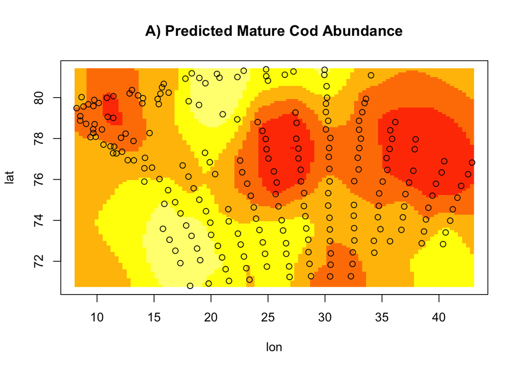

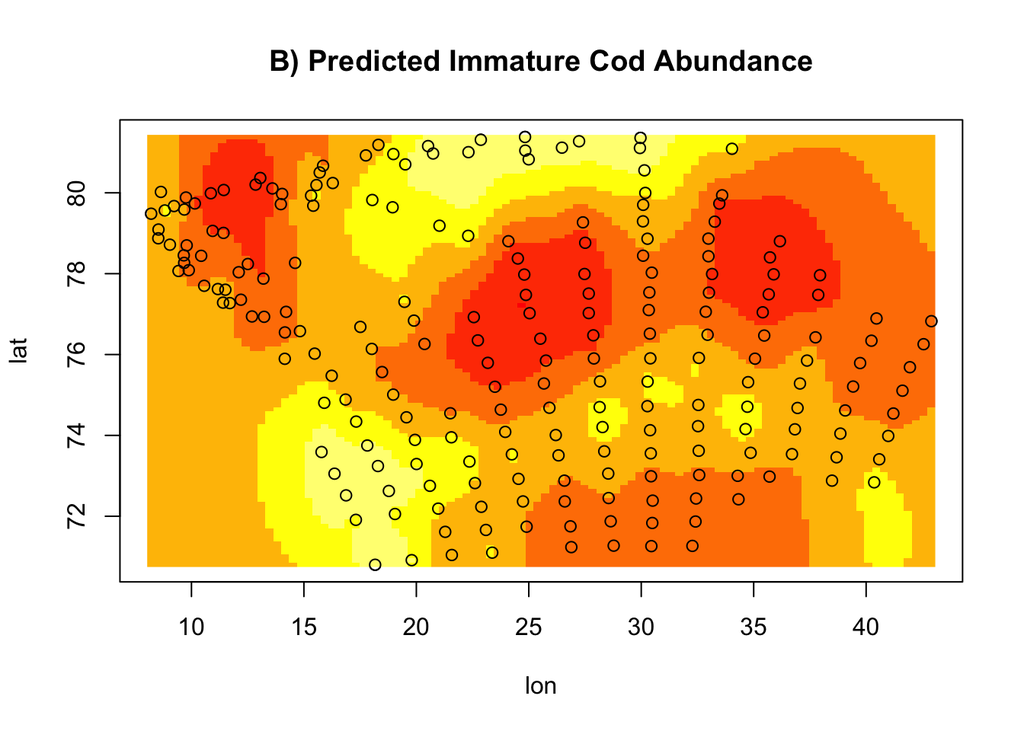

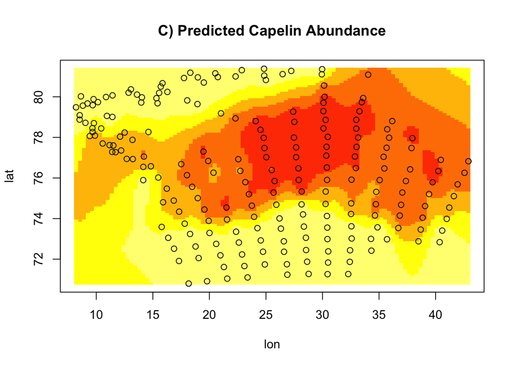

[figure not shown]

But what about the overlap?

# 5 Discussion

This work demonstrates a first step in exploring the data and provides me with insight. There are a number of next steps I want to talk to continue to explore the data and best address the research questions. The next steps are to:

1. Fix map projections so that the survey sites and reference coastline correctly line up.
2. Quantify species overlap.
3. Integrate spatial components and overlap into R-INLA (maybe JAGS, too.)
4. Add temporal component to look at changes over years or between seasonal surveys. The dataset available covers 2004-2015.
5. Find available data on zooplankton distribution and ice coverage to add to the model.

# 6 References

Burrows MT, Bates AE, Costello MJ, Edwards M, Edgar GJ, Fox CJ, Halpern BS, Hiddink JG, Pinsky ML, Batt RD, Molinos JG, Payne BL, Schoeman DS, Stuart-Smith RD, Poloczanska ES (2019) Ocean community warming responses explained by thermal affinities and temperature gradients. Nat Clim Change 9:959–963.

Fall J, Ciannelli L, Skaret G, Johannesen E (2018) Seasonal dynamics of spatial distributions and overlap between Northeast Arctic cod (Gadus morhua) and capelin (Mallotus villosus) in the Barents Sea. PLoS ONE 13.

Friedland KD, Langan JA, Large SI, Selden RL, Link JS, Watson RA, Collie JS (2020) Changes in higher trophic level productivity, diversity and niche space in a rapidly warming continental shelf ecosystem. Sci Total Environ 704:135270.

Jolly GM, Hampton I (1990) A Stratified Random Transect Design for Acoustic Surveys of Fish Stocks. Can J Fish Aquat Sci 47:1282–1291.

Kleisner KM, Fogarty MJ, McGee S, Hare JA, Moret S, Perretti CT, Saba VS (2017) Marine species distribution shifts on the U.S. Northeast Continental Shelf under continued ocean warming. Prog Oceanogr 153:24–36.

Li P, Chen S (2016) A review on Gaussian Process Latent Variable Models. CAAI Trans Intell Technol 1:366–376.

Link J, Overholtz W, O’Reilly J, Green J, Dow D, Palka D, Legault C, Vitaliano J, Guida V, Fogarty M, Brodziak J, Methratta L, Stockhausen W, Col L, Griswold C (2008) The Northeast U.S. continental shelf Energy Modeling and Analysis exercise (EMAX): Ecological network model development and basic ecosystem metrics. J Mar Syst 74:453–474.

Link JS, Bogstad B, Sparholt H, Lilly GR (2009) Trophic role of Atlantic cod in the ecosystem. Fish Fish 10:58–87.

Morley JW, Selden RL, Latour RJ, Frölicher TL, Seagraves RJ, Pinsky ML (2018) Projecting shifts in thermal habitat for 686 species on the North American continental shelf. PLOS ONE 13:e0196127. National Research Council W (1998) Improving fish stock assessments.

Nye JA, Link JS, Hare JA, Overholtz WJ (2009) Changing spatial distribution of fish stocks in relation to climate and population size on the Northeast United States continental shelf. Mar Ecol Prog Ser 393:111–129.

Overholtz W, Link J (2009) A simulation model to explore the response of the Gulf of Maine food web to large-scale environmental and ecological changes. Ecol Model 220:2491–2502.

Perretti CT, Thorson JT (2019) Spatio-temporal dynamics of summer flounder (Paralichthys dentatus) on the Northeast US shelf. Fish Res 215:62–68.

R Core Team (2017) R: A language and environment for statistical computing. http://www.R-project.org/

Rue H, Martino S, Chopin N (2009) Approximate Bayesian inference for latent Gaussian models by using integrated nested Laplace approximations. J R Stat Soc Ser B Stat Methodol 71:319–392.

Thorson JT, Barnett LAK (2017) Comparing estimates of abundance trends and distribution shifts using single- and multispecies models of fishes and biogenic habitat. ICES J Mar Sci 74:1311–1321.